# Chapter 2: Linear Models for Financial Time Series (2)

Weixaing Jing

December 18, 2017

This is note for Ruey S. Tsay’s R instruction on fincncial time series, chapter 2. For further knowledge on linear time series analysis, please refer to Tsay’s book: [An Introduction to Analysis of Financial Data with R (2010)](https://www.amazon.com/Introduction-Analysis-Financial-Data/dp/0470890819/ref=sr_1_3?ie=UTF8&qid=1512551660&sr=8-3&keywords=ruey+tsay) or visit his [website for the book and code](http://faculty.chicagobooth.edu/ruey.tsay/teaching/introTS/).

# 1 AR models

The traditional AR(1) model is in the form
$$x_t = \beta_0 + \beta_1 x_{t-1} + \varepsilon_t$$
where $\{ \varepsilon_t \}$ is a white noise with distribution $\mathbb{N}[0, \sigma^2]$.

I see it as a special case of linear regression and most of the conclusion and theories can apply to this model.

It’s trivial to calculate $\{ x_t\}$’s expectation and variance under the assumption of weakly stationary.

In general, the AR(p) model is
$$x_t =\beta_0 + \beta_1 x_{t-1} + \beta_2 x_{t-2} + \dots + \beta_k x_{t-p} + \varepsilon_t$$

## 1.1 AR(1) model

The $\{ x_t\}$ is weakly stationary is an important assumption and besed on that

$$\begin{align*}
\mathbf{E}[x_t]
&= \beta_0 + \beta_1 \mathbf{E}[x_{t-1}] +\mathbf{E}[\varepsilon_t]\\
&\Rightarrow \mathbf{E}[x_t] = \frac{\beta_0}{1-\beta_1}
\end{align*}$$

So

1. $\mathbf{E}[x_t]$ exists iff $\beta_1 \neq 1$.
2. $\mathbf{E}[x_t] = 0$ iff $\beta_0 = 0$.

Furthermore, we have
$$\begin{align*}
x_t - \mu
&= \beta_1(x_{t-1} - \mu) + \varepsilon_t\\
&= \beta_1(\beta_1 (x_{t-2}-\mu) + \varepsilon_{t-1}) + \varepsilon_t\\
& \dots\\
&= \sum_{k=0}^{\infty} \beta_1^k \varepsilon_{t-k}
\end{align*}$$

Here we see $x_t - \mu$ is a linear combination of iid white noise. And we could refer to former [note](http://weixiang-jing.netlify.com/post/2017/12/02/saturday/linear-models-for-financial-time-series-1/)’s ACF part, $x_t = \mu + \sum_{i=1}^{\infty} \psi_i a_{t-i}$, in which $\psi_k = \beta_1^k$.

By independence of $\{\varepsilon_t\}$, we have
$$Cov(x_{t-1}, \varepsilon_{t+k}) = Cov(x_{t-1}, \varepsilon_t) = \mathbf{E}[(x_{t-1} - \mu)\varepsilon_t] = 0$$

Therefore,
$$Var(x_t) = Var(\beta_1(x_{t-1} - \mu) + \varepsilon_t) = \beta_1^2 Var(x_{t-1}) + Var(\varepsilon_t)$$

Based on our weakly stationary assumption, $Var(x_t) = Var(x_{t-1})$ leads to
$$\gamma_0 = Var(x_t) = \frac{\sigma^2}{1- \beta_1^2}$$
.

Here we find a interesting conclusion that to let $Var(x_t) \geq 0$, $\beta_1^2 < 1$, i.e. $|\beta_1| < 1$, which satisfies our required weakly stationary assumption.

From another point of view, since iid $\{\varepsilon_t\} \sim \mathbb{N}[0, \sigma^2]$ and
$$\gamma_l = Cov(x_t, x_{t-l}) = \sigma^2 \sum_{j=0}^{\infty}\psi_j \psi_{j+l} = \sigma^2 \sum_{j=0}^{\infty} \beta_1^{2j+l} < \infty$$

we have

$$\begin{align*}
|\beta_1| < 1
&\Rightarrow x_t - \mu = \sum_{k=0}^{\infty} \beta_1^k \varepsilon_{t-k}\\
&\Rightarrow \mathbf{E}[x_t], Var(x_t) < \infty \quad \text{invariant of }t\\
&\Rightarrow acf(x_t) < \infty
\end{align*}$$

Thus the model is weakly stationary.

And we must note that

1. Under the assumption that elements of $\{x_t\}$ are iid and $\mathbf{E}[x_t^2] < \infty$, $\hat{\rho}_k \rightarrow \mathbb{N}[0, \frac{1}{T}]$. But if we have $\forall k>0, \rho_k = 0$, we can’t draw conclusion that elements $\{x_t\}$ is iid.
2. “What’s the definition or iff condition that a AR(1) is weakly stationary?” Here in book, it seems that author shows us that $Cov, \mathbf{E}, Var < \infty \Longleftrightarrow |\beta_1| <1$, which leads to weakly stationary.
3. When doing HW of MFE402, I come across a problem proving $Var(\hat{\rho}_k) \rightarrow \frac{1}{T}$ asymptotically. But in another reference online I read, it shows that
   $$Var(\hat{\rho_k}) =
   \begin{cases}
   \frac{1}{T} & k =1\\
   (1+ 2 \sum_{i=1}^{k-1}\hat{\rho}_i^2)/T & k >1
   \end{cases}$$
   This need further examining.

# 2 AR models property

## 2.1 AR(1) model property

Since $x_t$ is a linear combination of $\varepsilon_i$, if we multiple $\varepsilon_t$ on both sides of AR(1) model, we get
$$\begin{align*}
\mathbf{E}[\varepsilon_t(x_t - \mu)]
&= \beta_1 \mathbf{E}[\varepsilon_t (x_{t-1}- \mu)] + \mathbf{E}[\varepsilon_t^2]
&= \sigma^2
\end{align*}$$
Based on this, we also get the relationship of covariance of $\{x_t\}$ as
$$\begin{align*}
\gamma_k
&=\mathbf{E}[(x_t - \mu)(x_{t-k}- \mu)]\\
&= \beta_1 \mathbf{E}[(x_{t-1} - \mu)(x_{t-k} - \mu)] + \mathbf{E}[(x_{t-k}- \mu)\varepsilon_t]
\end{align*}$$

Thus
$$\gamma_k =
\begin{cases}
\beta_1 \gamma_1 + \sigma^2 & k =0\\
\beta_1 \gamma_{k-1} & k >0
\end{cases}$$

Since $\gamma_0 = 1$, we have acf relationship as $\rho_k = \beta_1^{k}$.

```r
set.seed(1234)
N <- 500
x <- numeric(N)
y <- numeric(N)
x[1] <- 1
y[1] <- 1
for(i in 2:N){
  x[i] <- -.9*x[i-1]+rnorm(1, 0, 0.5)
  y[i] <- .9*y[i-1]+rnorm(1, 0, 0.5)
}
```

For $-1<\beta_1 <0$, we have acf as

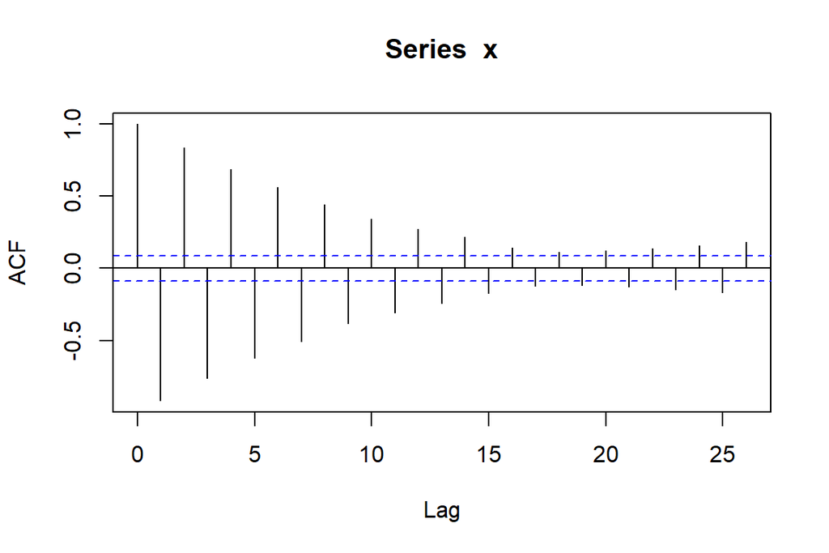

```r
acf(x)
```

For $0 <\beta_1 <1$, we have acf as

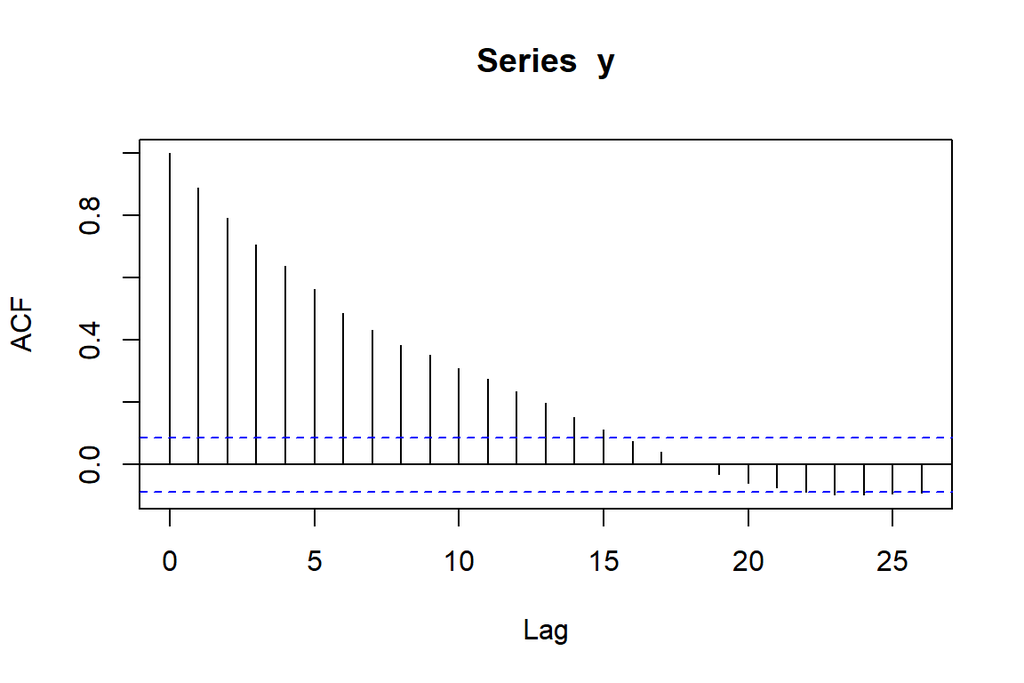

```r
acf(y)
```